# Covid Cases per state by political affiliation

Ayush Arora

12/2/2020

#### Importing political affiliation by state data from CSV

```r
df = read.csv("https://raw.githubusercontent.com/Araisedtotwo/Final-Project/main/raw_data.csv",skip = 2, header = T)
```

#### Cleaning the data - Removing extra columns

```r
df$State.Senate.Majority.Political.Affiliation <- NULL
df$State.House.Majority.Political.Affiliation <- NULL
df$State.Attorney.General.Political.Affiliation  <- NULL
df$State.Insurance.Commissioner.Political.Affiliation  <- NULL
df$Footnotes   <- NULL
head(df,5)
```

```
##     Location State.Code Governor.Political.Affiliation latitude  longitude
## 1    Alabama         AL                     Republican 32.31823  -86.90230
## 2     Alaska         AK                     Republican 63.58875 -154.49306
## 3    Arizona         AZ                     Republican 34.04893 -111.09373
## 4   Arkansas         AR                     Republican 35.20105  -91.83183
## 5 California         CA                       Democrat 36.77826 -119.41793
```

#### Renaming column “State.Code” to “state” and

#### “Governor.Political.Affiliation” to “affiliation” for join

```r
df2 <- df %>%
  rename(
    state = State.Code,
    affiliation = Governor.Political.Affiliation
    )
head(df2,5)
```

```
##     Location state affiliation latitude  longitude
## 1    Alabama    AL  Republican 32.31823  -86.90230
## 2     Alaska    AK  Republican 63.58875 -154.49306
## 3    Arizona    AZ  Republican 34.04893 -111.09373
## 4   Arkansas    AR  Republican 35.20105  -91.83183
## 5 California    CA    Democrat 36.77826 -119.41793
```

#### View Invalid rows at the bottom of CSV

```r
tail(df2,4)
```

```
##                                                                                                                                                                 Location
## 68
## 69                                                                                                                                                             Footnotes
## 70 1. The District of Columbia (DC) has an elected Mayor. Additionally, the legislative branch of DC is a 13 member City Council. The Council has a Democratic majority.
## 71                                                                                                   2. Nebraska has a Unicameral system with no political affiliations.
##    state affiliation latitude longitude
## 68                         NA        NA
## 69                         NA        NA
## 70                         NA        NA
## 71                         NA        NA
```

#### Cleaning the data - Removing invalid rows from the bottom (not part of the analysis)

```r
cleaned <- head(df2,51)
head(cleaned,5)
```

```
##     Location state affiliation latitude  longitude
## 1    Alabama    AL  Republican 32.31823  -86.90230
## 2     Alaska    AK  Republican 63.58875 -154.49306
## 3    Arizona    AZ  Republican 34.04893 -111.09373
## 4   Arkansas    AR  Republican 35.20105  -91.83183
## 5 California    CA    Democrat 36.77826 -119.41793
```

### Data Source 2 - API

#### Extracting COVID data from API for merging with political affiliation dataset

```r
cases <- fromJSON("https://data.cdc.gov/resource/9mfq-cb36.json?submission_date=2020-10-31", flatten = TRUE)
head(cases,5)
```

```
##           submission_date state tot_cases conf_cases prob_cases new_case
## 1 2020-10-31T00:00:00.000    ID     64608    56399.0       8209    798.0
## 2 2020-10-31T00:00:00.000    MD    146145       <NA>       <NA>    864.0
## 3 2020-10-31T00:00:00.000    LA    186649       <NA>       <NA>      0.0
## 4 2020-10-31T00:00:00.000    FL    791997       <NA>       <NA>   2283.0
## 5 2020-10-31T00:00:00.000    KY    107219    90062.0      17157   1977.0
##   pnew_case tot_death conf_death prob_death new_death pnew_death
## 1       233       629      585.0         44       3.0          0
## 2         0      4152     4004.0        148       5.0          1
## 3         0      5919     5705.0        214       0.0          0
## 4       594     16761       <NA>       <NA>      41.0          0
## 5       427      1485     1463.0         22       9.0          1
##                created_at consent_cases consent_deaths
## 1 2020-11-01T15:03:08.429         Agree          Agree
## 2 2020-11-01T15:03:08.429           N/A          Agree
## 3 2020-11-01T15:03:08.429     Not agree          Agree
## 4 2020-11-01T15:03:08.429     Not agree      Not agree
## 5 2020-11-01T15:03:08.429         Agree          Agree
```

#### Formatting Date

```r
cases[[1]] <- substr(cases$submission_date, 0, 10)
head(cases,5)
```

```
##   submission_date state tot_cases conf_cases prob_cases new_case pnew_case
## 1      2020-10-31    ID     64608    56399.0       8209    798.0       233
## 2      2020-10-31    MD    146145       <NA>       <NA>    864.0         0
## 3      2020-10-31    LA    186649       <NA>       <NA>      0.0         0
## 4      2020-10-31    FL    791997       <NA>       <NA>   2283.0       594
## 5      2020-10-31    KY    107219    90062.0      17157   1977.0       427
##   tot_death conf_death prob_death new_death pnew_death              created_at
## 1       629      585.0         44       3.0          0 2020-11-01T15:03:08.429
## 2      4152     4004.0        148       5.0          1 2020-11-01T15:03:08.429
## 3      5919     5705.0        214       0.0          0 2020-11-01T15:03:08.429
## 4     16761       <NA>       <NA>      41.0          0 2020-11-01T15:03:08.429
## 5      1485     1463.0         22       9.0          1 2020-11-01T15:03:08.429
##   consent_cases consent_deaths
## 1         Agree          Agree
## 2           N/A          Agree
## 3     Not agree          Agree
## 4     Not agree      Not agree
## 5         Agree          Agree
```

#### Joining/Merging the dataframes

```r
final_df <- merge(cleaned, cases)
head(final_df, 5)
```

```
##   state   Location affiliation latitude  longitude submission_date tot_cases
## 1    AK     Alaska  Republican 63.58875 -154.49306      2020-10-31     15274
## 2    AL    Alabama  Republican 32.31823  -86.90230      2020-10-31    192285
## 3    AR   Arkansas  Republican 35.20105  -91.83183      2020-10-31    112190
## 4    AZ    Arizona  Republican 34.04893 -111.09373      2020-10-31    245946
## 5    CA California    Democrat 36.77826 -119.41793      2020-10-31    922005
##   conf_cases prob_cases new_case pnew_case tot_death conf_death prob_death
## 1       <NA>       <NA>    437.0         0        82       <NA>       <NA>
## 2   164295.0      27990   1789.0       214      2967     2761.0        206
## 3       <NA>       <NA>   1316.0       239      1925       <NA>       <NA>
## 4   240130.0       5816   1901.0       127      5979     5664.0        315
## 5       <NA>       <NA>   5087.0         0     17626       <NA>       <NA>
##   new_death pnew_death              created_at consent_cases consent_deaths
## 1       1.0          0 2020-11-01T15:03:08.429           N/A            N/A
## 2      35.0          9 2020-11-01T15:03:08.429         Agree          Agree
## 3      25.0          4 2020-11-01T15:03:08.429     Not agree      Not agree
## 4      45.0         22 2020-11-01T15:03:08.429         Agree          Agree
## 5      55.0          0 2020-11-01T15:03:08.429     Not agree      Not agree
```

#### Converting total_cases and total_deaths to numeric

```r
final_df <- transform(final_df, tot_cases = as.numeric(tot_cases))
final_df <- transform(final_df, tot_death = as.numeric(tot_death))
head(final_df, 5)
```

```
##   state   Location affiliation latitude  longitude submission_date tot_cases
## 1    AK     Alaska  Republican 63.58875 -154.49306      2020-10-31     15274
## 2    AL    Alabama  Republican 32.31823  -86.90230      2020-10-31    192285
## 3    AR   Arkansas  Republican 35.20105  -91.83183      2020-10-31    112190
## 4    AZ    Arizona  Republican 34.04893 -111.09373      2020-10-31    245946
## 5    CA California    Democrat 36.77826 -119.41793      2020-10-31    922005
##   conf_cases prob_cases new_case pnew_case tot_death conf_death prob_death
## 1       <NA>       <NA>    437.0         0        82       <NA>       <NA>
## 2   164295.0      27990   1789.0       214      2967     2761.0        206
## 3       <NA>       <NA>   1316.0       239      1925       <NA>       <NA>
## 4   240130.0       5816   1901.0       127      5979     5664.0        315
## 5       <NA>       <NA>   5087.0         0     17626       <NA>       <NA>
##   new_death pnew_death              created_at consent_cases consent_deaths
## 1       1.0          0 2020-11-01T15:03:08.429           N/A            N/A
## 2      35.0          9 2020-11-01T15:03:08.429         Agree          Agree
## 3      25.0          4 2020-11-01T15:03:08.429     Not agree      Not agree
## 4      45.0         22 2020-11-01T15:03:08.429         Agree          Agree
## 5      55.0          0 2020-11-01T15:03:08.429     Not agree      Not agree
```

#### Extracting data for the Republican States

```r
republican <- final_df[final_df$affiliation == 'Republican',]
head(republican,3)
```

```
##   state Location affiliation latitude  longitude submission_date tot_cases
## 1    AK   Alaska  Republican 63.58875 -154.49306      2020-10-31     15274
## 2    AL  Alabama  Republican 32.31823  -86.90230      2020-10-31    192285
## 3    AR Arkansas  Republican 35.20105  -91.83183      2020-10-31    112190
##   conf_cases prob_cases new_case pnew_case tot_death conf_death prob_death
## 1       <NA>       <NA>    437.0         0        82       <NA>       <NA>
## 2   164295.0      27990   1789.0       214      2967     2761.0        206
## 3       <NA>       <NA>   1316.0       239      1925       <NA>       <NA>
##   new_death pnew_death              created_at consent_cases consent_deaths
## 1       1.0          0 2020-11-01T15:03:08.429           N/A            N/A
## 2      35.0          9 2020-11-01T15:03:08.429         Agree          Agree
## 3      25.0          4 2020-11-01T15:03:08.429     Not agree      Not agree
```

#### Extracting data for the Democrat States

```r
democrat <- final_df[final_df$affiliation == 'Democrat',]
head(democrat,3)
```

```
##   state    Location affiliation latitude  longitude submission_date tot_cases
## 5    CA  California    Democrat 36.77826 -119.41793      2020-10-31    922005
## 6    CO    Colorado    Democrat 39.55005 -105.78207      2020-10-31    107350
## 7    CT Connecticut    Democrat 41.60322  -73.08775      2020-10-31     71207
##   conf_cases prob_cases new_case pnew_case tot_death conf_death prob_death
## 5       <NA>       <NA>   5087.0         0     17626       <NA>       <NA>
## 6   100220.0       7130   2924.0       101      2285     1893.0        392
## 7    67519.0       3688      0.0         0      4616     3708.0        908
##   new_death pnew_death              created_at consent_cases consent_deaths
## 5      55.0          0 2020-11-01T15:03:08.429     Not agree      Not agree
## 6       7.0          0 2020-11-01T15:03:08.429         Agree          Agree
## 7       0.0          0 2020-11-01T15:03:08.429         Agree          Agree
```

#### Total cases for republican states

```r
republican$tot_cases
```

```
##  [1]  15274 192285 112190 245946 791997 388993 127966  64608 179358 164417
## [11] 146145 185535 120500  45043  70732  11084 215697 129191 176612  45992
## [21] 260672 900596 114656   2157  24460  13298
```

```r
length(republican$tot_cases)
```

```
## [1] 26
```

#### Total cases for Democrat states

```r
democrat$tot_cases
```

```
##  [1] 922005 107350  71207  17266  25126  14995 416559  85181 107219 186649
## [11]   6668 197406 148472  32801 274635 249931  46490 100763 244271  44921
## [21] 208027  32874 182393 107501 237870
```

```r
length(democrat$tot_cases)
```

```
## [1] 25
```

#### Summary for Democratic States

```r
summary(democrat$tot_cases)
```

```
##    Min. 1st Qu.  Median    Mean 3rd Qu.    Max.
##    6668   44921  107350  162743  208027  922005
```

#### Summary for Republican States

```r
summary(republican$tot_cases)
```

```
##    Min. 1st Qu.  Median    Mean 3rd Qu.    Max.
##    2157   50646  128578  182516  190598  900596
```

#### Box Plot : Covid Cases Distribution by states’ political party affiliation

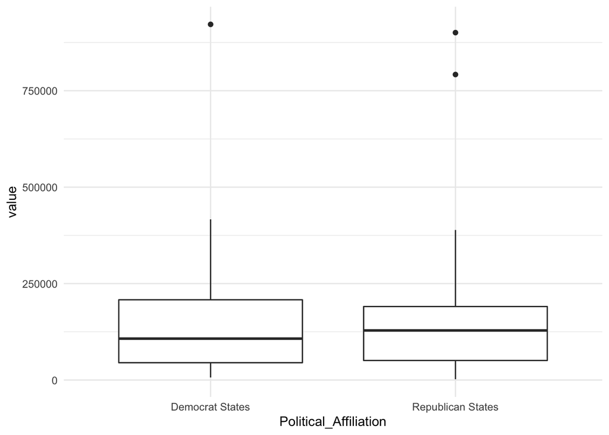

```r
dat_ggplot <- data.frame(
  value = c(republican$tot_cases,democrat$tot_cases),
  Political_Affiliation = c(rep("Republican States",26), rep("Democrat States", 25))
)

ggplot(dat_ggplot) +
  aes(x = Political_Affiliation, y = value) +
  geom_boxplot() +
  theme_minimal()
```

#### T-test: Check whether average total cases in Democrat vs Republican affiliated states are significantly different

```r
t.test(republican$tot_cases, y = democrat$tot_cases,alternative = c("two.sided"),
       mu = 0, paired = FALSE, var.equal = FALSE,
       conf.level = 0.95)
```

```
##
##  Welch Two Sample t-test
##
## data:  republican$tot_cases and democrat$tot_cases
## t = 0.34843, df = 48.543, p-value = 0.729
## alternative hypothesis: true difference in means is not equal to 0
## 95 percent confidence interval:
##  -94290.52 133835.19
## sample estimates:
## mean of x mean of y
##  182515.5  162743.2
```

#### Conclusion 1

- As can be seen from the box plot and the descriptive statistics, the median number of Covid Cases are nearly the same for the states affiliated to either party.
- Since the p-value of 0.729 is greater than the 5% level of significance from the T-test, the average number of cases in Republican states are not significantly different from the average number of cases in the Democrat states.

#### Analysis 2: Finding difference in average death proportion for states of different political party affiliation

#### Computing death proportion (percentage)

```r
final_df$death_percent <-  final_df$tot_death / final_df$tot_cases * 100

final_df %>%
  select(Location, affiliation, tot_death, tot_cases,death_percent)
```

```
##                Location affiliation tot_death tot_cases death_percent
## 1                Alaska  Republican        82     15274     0.5368600
## 2               Alabama  Republican      2967    192285     1.5430221
## 3              Arkansas  Republican      1925    112190     1.7158392
## 4               Arizona  Republican      5979    245946     2.4310214
## 5            California    Democrat     17626    922005     1.9117033
## 6              Colorado    Democrat      2285    107350     2.1285515
## 7           Connecticut    Democrat      4616     71207     6.4825087
## 8  District of Columbia    Democrat       646     17266     3.7414572
## 9              Delaware    Democrat       710     25126     2.8257582
## 10              Florida  Republican     16761    791997     2.1162959
## 11              Georgia  Republican      7979    388993     2.0511937
## 12               Hawaii    Democrat       218     14995     1.4538179
## 13                 Iowa  Republican      1716    127966     1.3409812
## 14                Idaho  Republican       629     64608     0.9735636
```

[output cut: 37 more lines]

#### Segregating affiliations for T-test

```r
republican2 <- final_df[final_df$affiliation == 'Republican',]
democrat2 <- final_df[final_df$affiliation == 'Democrat',]
summary(republican2$death_percent)
```

```
##    Min. 1st Qu.  Median    Mean 3rd Qu.    Max.
##  0.5268  1.0750  1.7921  1.9452  2.4271  6.0663
```

```r
summary(democrat2$death_percent)
```

```
##    Min. 1st Qu.  Median    Mean 3rd Qu.    Max.
##  0.8795  1.5941  2.1897  2.6418  3.6533  6.5418
```

#### T-test for death proportion

```r
t.test(republican2$death_percent, y = democrat2$death_percent,alternative = c("two.sided"),
       mu = 0, paired = FALSE, var.equal = FALSE,
       conf.level = 0.95)
```

```
##
##  Welch Two Sample t-test
##
## data:  republican2$death_percent and democrat2$death_percent
## t = -1.8162, df = 46.152, p-value = 0.07584
## alternative hypothesis: true difference in means is not equal to 0
## 95 percent confidence interval:
##  -1.46867675  0.07537615
## sample estimates:
## mean of x mean of y
##  1.945193  2.641844
```

### Death Percantage Visualizations

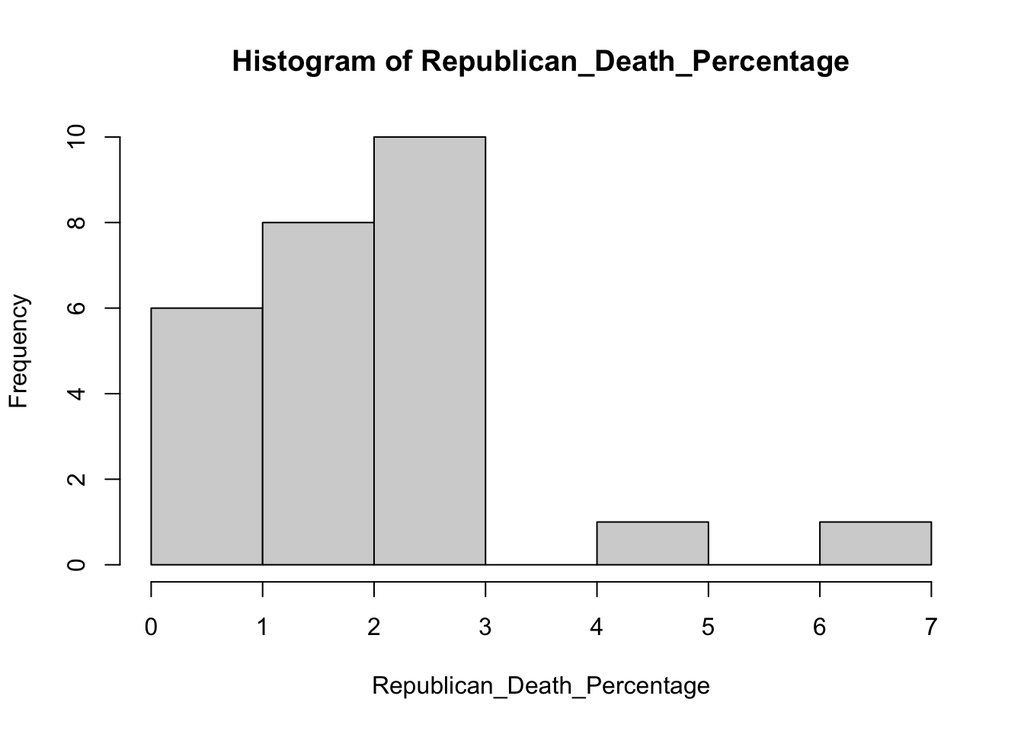

```r
Republican_Death_Percentage <- republican2$death_percent
hist(Republican_Death_Percentage)
```

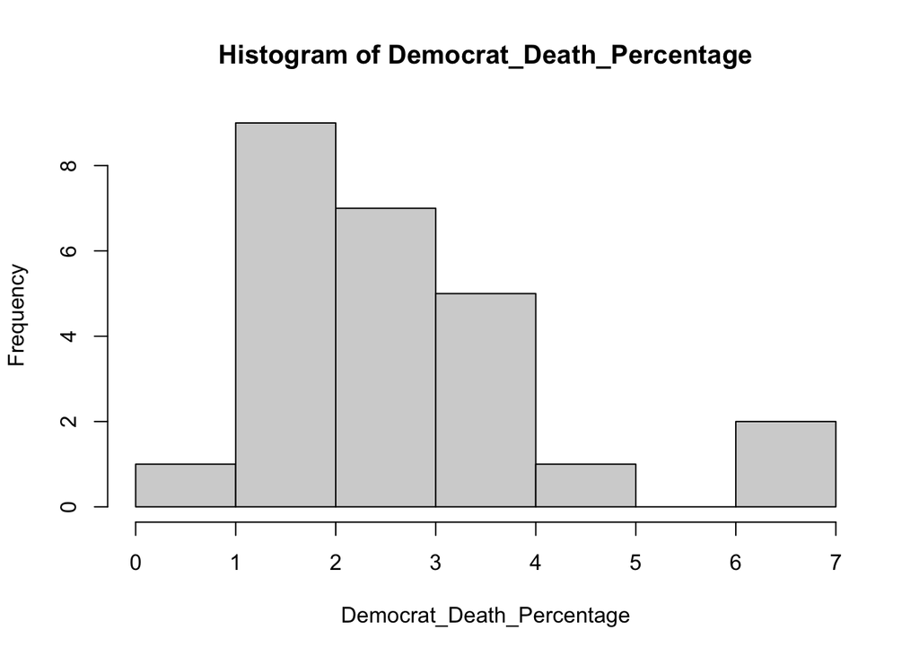

```r
Democrat_Death_Percentage <- democrat2$death_percent
hist(Democrat_Death_Percentage)
```

```r
usa <- map_data("state")
```

#### Additional Feature : Plotting Death proportions using ggmap

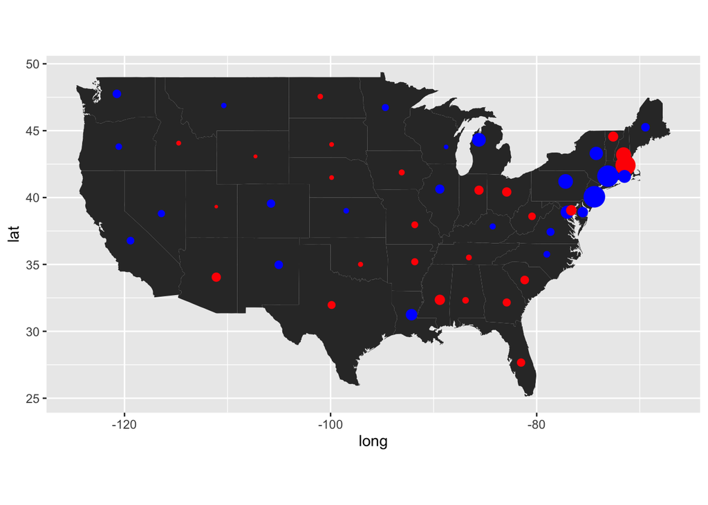

```r
final_df2<-final_df[!(final_df$Location=="Alaska" | final_df$Location=="Hawaii"),]

ggplot() + geom_polygon(data = usa, aes(x=long, y = lat, group = group)) +
  coord_fixed(1.3) +
  geom_point(data = final_df2, size=final_df2$death_percent, mapping = aes(x = longitude, y = latitude), color = ifelse(final_df2$affiliation =="Republican",'red','blue'))
```